# Analysis of DexaFit Client Booking Data

by John Akwei, Data Science Specialist

Tuesday, September 15, 2015

## Synopsis

The objective of this document is analysis of 5 DexaFit booking data spreadsheets. The spreadsheet data is analyzed in order to gain an understanding of;  
1) the target demographic  
2) seasonal visiting trends  
3) rate of growth month over month  
(Chicago, San Francisco, and Atlanta only)

The data contains client identification information, and appointment-related questions, that are answered via multiple selection, and by comment from the client. The Categories of the Booking Data include Profile, Reference, Start time, Cancelled, Status, NAME, Last Name, Gender, Email, Phone Number, What are we testing this visit?, Is this a new test or a follow-up assessment?, Reason for visit, How did you learn about DexaFit?.

R programming language processing of the Data was performed to extract the conclusions in this Document. In order to increase comprehensibility of the Document, most of the R coding for data analysis was not printed as part of the Document.

The sections of this Document include:  
1) Data import  
2) Data Overview  
3) Target Demographic Analysis  
4) Seasonal Visiting Trends  
5) Monthly Rate of Growth Analysis

## 1) Data import:

```r
chicagobooking <- read.csv("chi-booking-form-data.csv", check.names=F)
chicagobookingplus <- read.csv("chi-booking-additional-data.csv", check.names=F)
sanfranciscobooking <- read.csv("sf-booking-form-data.csv", check.names=F)
sanfranciscobookingplus <- read.csv("sf-booking-additional-data.csv", check.names=F)
atlantabooking <- read.csv("atl-booking-form-data.csv", check.names=F)
atlantabookingplus <- read.csv("atl-booking-additional-data.csv", check.names=F)
dallasbooking <- read.csv("dallas-booking-form-data.csv", check.names=F)
dallasbookingplus <- read.csv("dallas-booking-additional-data.csv", check.names=F)
highlandparkbooking <- read.csv("hp-booking-form-data.csv", check.names=F)
highlandparkbookingplus <- read.csv("hp-booking-additional-data.csv", check.names=F)
```

## 2) Data Overview:

## Chicago Data Overview

#### 1530 clients examined

#### 17 data categories

#### Chicago booking data indentification information:

[1] “Profile” [2] “Reference” [3] “Start time”  
[4] “Cancelled” [5] “Status” [6] “NAME”  
[7] “Last Name:” [8] “Gender:” [9] “Email:”  
[10] “Phone Number:” [16] “(suggested text) Please enter your name:”  
[17] “Your Email:”

#### Chicago booking data questions:

[11] “What are we testing this visit?”  
[12] “Is this a new test or a follow-up assessment?”  
[13] “Reason for visit:”  
[14] “How did you learn about DexaFit?”  
[15] “Please list any questions or comments below:”

## San Francisco Data Overview

#### 496 clients examined

#### 14 data categories

#### San Francisco booking data indentification information:

[1] “Profile” [2] “Reference” [3] “Start time”  
[4] “Cancelled” [5] “Status” [6] “NAME”  
[7] “Last Name:” [8] “Gender:” [9] “Email:”  
[10] “Phone Number:”

#### San Francisco booking data questions:

[11] “What are we testing this visit?”  
[12] “Is this a new test or a follow-up assessment?”  
[13] “Reason for visit:”  
[14] “How did you learn about DexaFit?

## Atlanta Data Overview

#### 296 clients examined

#### 16 data categories

#### Atlanta booking data indentification information:

[1] “Profile” [2] “Reference” [3] “Start time”  
[4] “Cancelled” [5] “Status” [6] “NAME”  
[7] “Last Name:” [8] “Gender:” [9] “Email:”  
[10] “Phone Number:”  
[16] “Your Email:”

#### Atlanta booking data questions:

[11] “What are we testing this visit?”  
[12] “Is this a new test or follow-up assessment?”  
[13] “Reason for visit:”  
[14] “How did you learn about DexaFit?”  
[15] “Please list any questions or comments below:”

## Dallas Data Overview

#### 107 clients examined

#### 14 data categories

#### Dallas booking data indentification information:

[1] “Profile” [2] “Reference” [3] “Start time”  
[4] “Cancelled” [5] “Status” [6] “NAME”  
[7] “Last Name:” [8] “Gender:” [9] “Email:”  
[10] “Phone Number:”

#### Dallas booking data questions:

[11] “What are we testing this visit?”  
[12] “Is this a new test or a follow-up assessment?”  
[13] “Reason for visit:”  
[14] “How did you learn about DexaFit?”

## Highland Park Data Overview

#### 89 clients examined

#### 15 data categories

#### Highland Park booking data indentification information:

[1] “Profile” [2] “Reference” [3] “Start time”  
[4] “Cancelled” [5] “Status” [6] “NAME”  
[7] “Last Name:” [8] “Gender:” [9] “Email:”  
[10] “Phone Number:”

#### Highland Park booking data questions:

[11] “What are we testing this visit?”  
[12] “Is this a new test or a follow-up assessment?”  
[13] “Reason for visit:”  
[14] “How did you learn about DexaFit?”  
[15] “Please enter any discount codes here.”

## 3) Target Demographic Analysis:

## Chicago:

#### Chicago demographics - Gender:

```
##   Male Female
##    892    617
```

#### Chicago - “What are we testing this visit?”:

```
##     DXA MetaFit     RMR     VO2
##    1399     390     442     402
```

#### Chicago - “What are we testing this visit?” - Male:

```
##     DXA MetaFit     RMR     VO2
##     830     228     252     235
```

#### Chicago - “What are we testing this visit?” - Female:

```
##     DXA MetaFit     RMR     VO2
##     569     162     190     167
```

#### Chicago - “Is this a new test or a follow-up assessment?”:

```
##       New Follow-up
##      1101       362
```

#### Chicago - “Reason for visit”:

```
##      body  baseline  body fat Follow-up
##       271       113       132       109
```

#### Chicago - “How did you learn about DexaFit?”

```
##  Google Groupon  Search  Friend
##     183     177      82      42
```

## San Francisco

#### San Francisco demographics - Gender:

```
##   Male Female
##    319    177
```

#### San Francisco - “What are we testing this visit?”:

```
##     DXA MetaFit     RMR     VO2
##     483     185     194     186
```

#### San Francisco - “What are we testing this visit?” - Male:

```
##     DXA MetaFit     RMR     VO2
##     312     110     115     111
```

#### San Francisco - “What are we testing this visit?” - Female:

```
##     DXA MetaFit     RMR     VO2
##     171      75      79      75
```

#### San Francisco - “Is this a new test or a follow-up assessment?”:

```
##       New Follow-up
##       376       120
```

#### San Francisco - “Reason for visit”:

```
##      body  baseline  body fat Follow-up
##        93        50        43        15
```

#### San Francisco - “How did you learn about DexaFit?”

```
## Google Friend Search Online
##     46     20     18     11
```

## Atlanta

#### Atlanta demographics - Gender:

```
##   Male Female
##    163    131
```

#### Atlanta - “What are we testing this visit?”:

```
##     DXA MetaFit     RMR     VO2
##     281      92     103      92
```

#### Atlanta - “What are we testing this visit?” - Male:

```
##     DXA MetaFit     RMR     VO2
##     157      50      55      50
```

#### Atlanta - “What are we testing this visit?” - Female:

```
##     DXA MetaFit     RMR     VO2
##     124      42      48      42
```

#### Atlanta - “Is this a new test or a follow-up assessment?”:

```
##       New Follow-up
##       251        41
```

#### Atlanta - “Reason for visit”:

```
##      body  baseline  body fat Follow-up
##        52        32        23        15
```

#### Atlanta - “How did you learn about DexaFit?”

```
##   Google  Groupon   Online Internet
##       59       44       15       12
```

## Dallas

#### Dallas demographics - Gender:

```
##   Male Female
##     59     48
```

#### Dallas - “What are we testing this visit?”:

```
##     DXA MetaFit     RMR     VO2
##     102      32      35      34
```

#### Dallas - “What are we testing this visit?” - Male:

```
##     DXA MetaFit     RMR     VO2
##      58      14      14      15
```

#### Dallas - “What are we testing this visit?” - Female:

```
##     DXA MetaFit     RMR     VO2
##      44      18      21      19
```

#### Dallas - “Is this a new test or a follow-up assessment?”:

```
##       New Follow-up
##       101         6
```

#### Dallas - “Reason for visit”:

```
##      body  baseline  body fat Follow-up
##        14         5        10         5
```

#### Dallas - “How did you learn about DexaFit?”

```
##  Google Groupon  Jennie   Vince
##      17      18       6       3
```

## Highland Park

#### Highland Park demographics - Gender:

```
##   Male Female
##     52     37
```

#### Highland Park - “What are we testing this visit?”:

```
##     DXA MetaFit     RMR     VO2
##      82      34      41      34
```

#### Highland Park - “What are we testing this visit?” - Male:

```
##     DXA MetaFit     RMR     VO2
##      49      28      31      28
```

#### Highland Park - “What are we testing this visit?” - Female:

```
##     DXA MetaFit     RMR     VO2
##      33       6      10       6
```

#### Highland Park - “Is this a new test or a follow-up assessment?”:

```
##       New Follow-up
##        78        11
```

#### Highland Park - “Reason for visit”:

```
##      body  baseline  body fat Follow-up
##         5         9         4         5
```

#### Highland Park - “How did you learn about DexaFit?”

```
##     Groupon      Robbie Tim Ferriss         Web
##          11           7           3           4
```

## 4) Seasonal Visiting Trends:

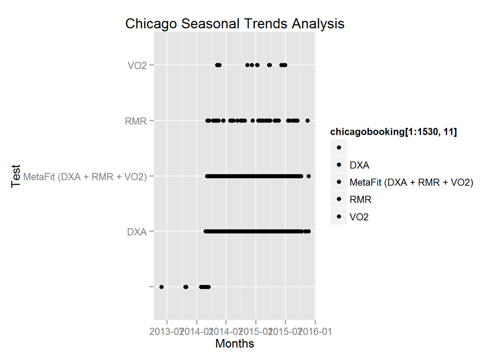

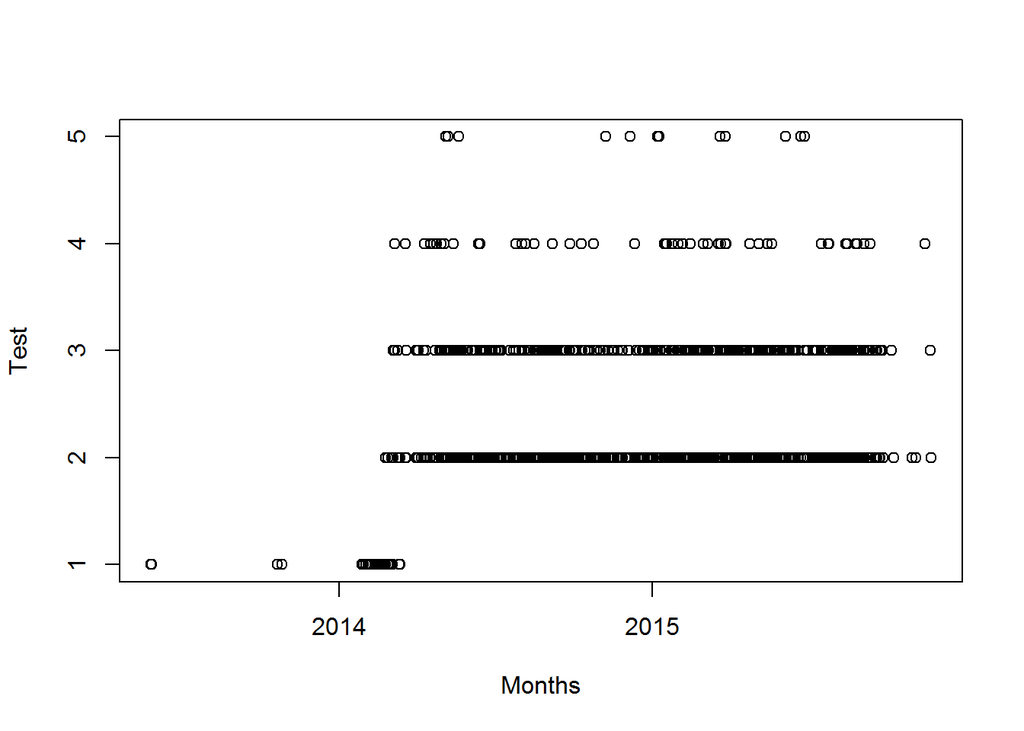

#### Conclusions:

The Seasonal Visiting Trends Charts for Chicago show the distribution of appointment types for 1530 appointments, over a 2 year period.

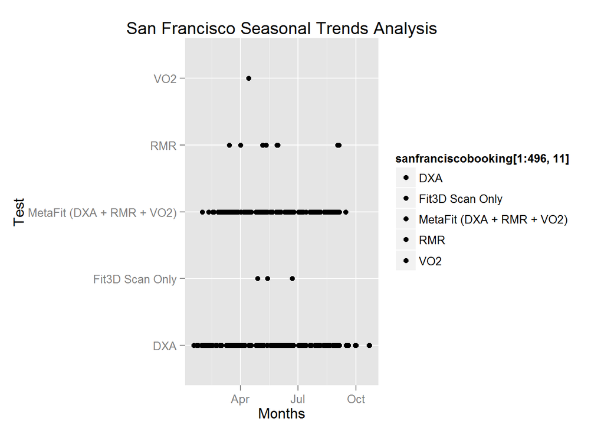

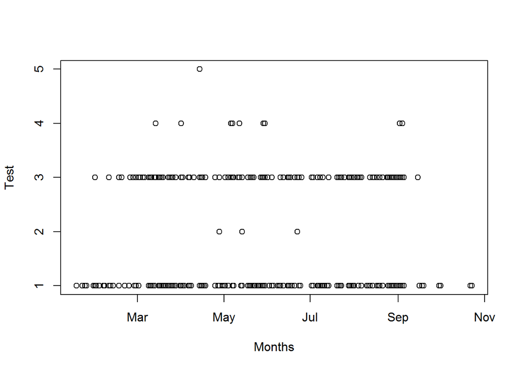

#### Conclusions:

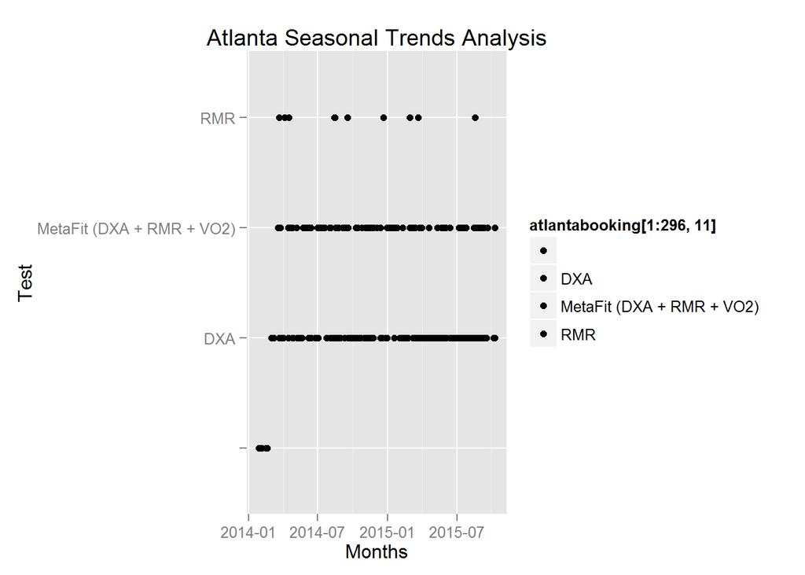

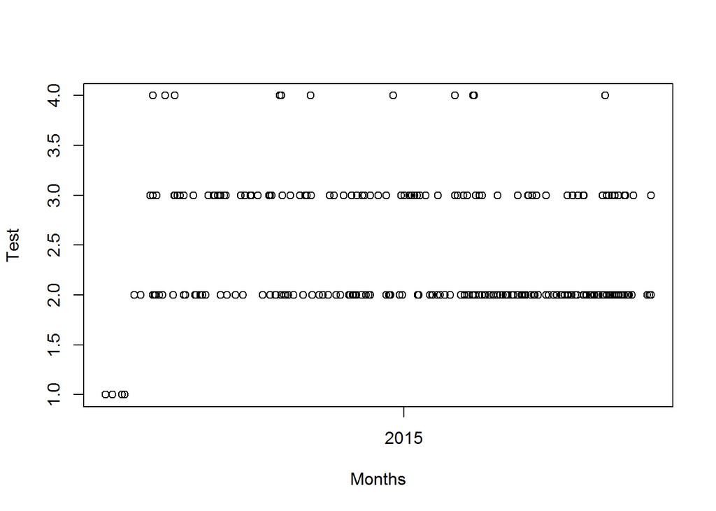

## 5) Monthly Rate of Growth Analysis:

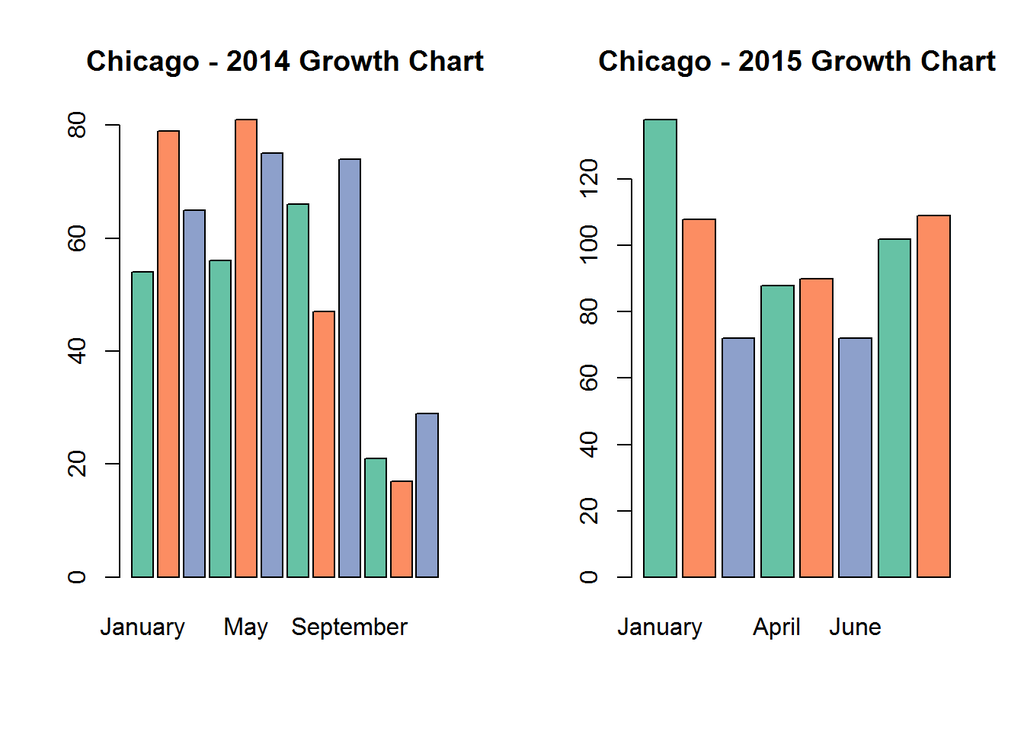

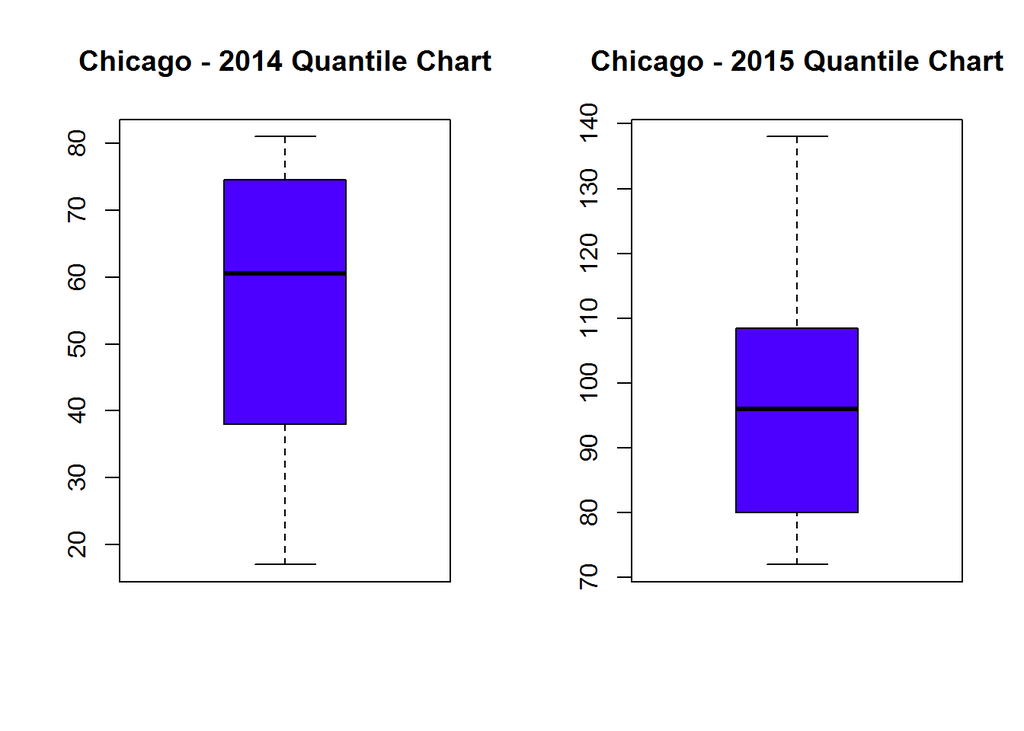

#### Chicago 2014 Quantile Table:

```
##    0%   25%   50%   75%  100%
## 17.00 42.50 60.50 74.25 81.00
```

#### Chicago 2015 Quantile Table:

```
##     0%    25%    50%    75%   100%
##  72.00  84.00  96.00 108.25 138.00
```

#### Chicago Month-over-Month Growth Rate:

January, 2014 to January, 2015:

```r
(ch115 - ch114) / ch115 * 100
```

```
## [1] 60.86957
```

February, 2014 to February, 2015:

```r
(ch215 - ch214) / ch215 * 100
```

```
## [1] 26.85185
```

March, 2014 to March, 2015:

```r
(ch315 - ch314) / ch315 * 100
```

```
## [1] 9.722222
```

April, 2014 to April, 2015:

```r
(ch415 - ch414) / ch415 * 100
```

```
## [1] 36.36364
```

May, 2014 to May, 2015:

```r
(ch515 - ch514) / ch515 * 100
```

```
## [1] 10
```

June, 2014 to June, 2015:

```r
(ch615 - ch614) / ch615 * 100
```

```
## [1] -4.166667
```

July, 2014 to July, 2015:

```r
(ch715 - ch714) / ch715 * 100
```

```
## [1] 35.29412
```

August, 2014 to August, 2015:

```r
(ch815 - ch814) / ch815 * 100
```

```
## [1] 56.88073
```

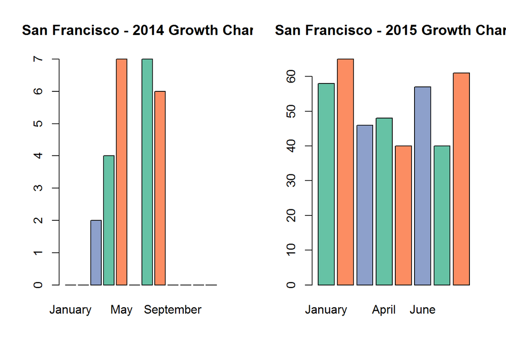

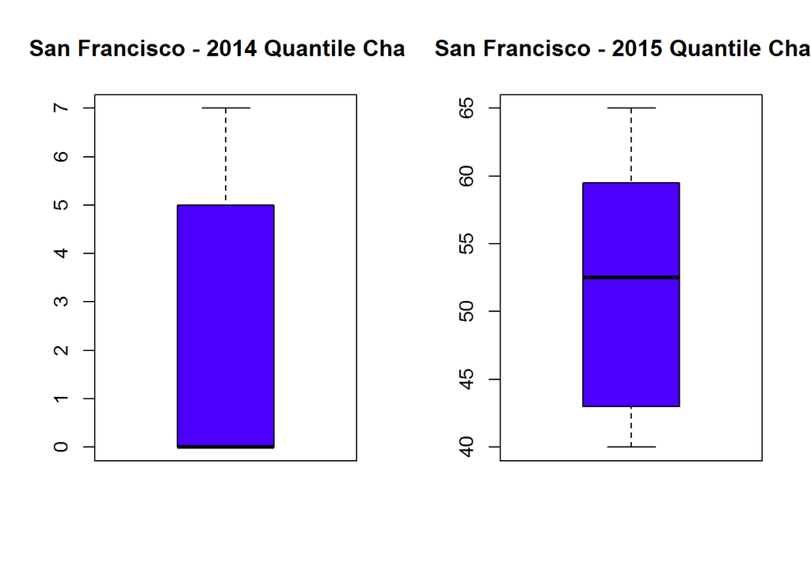

#### San Francisco 2015 Quantile Table:

```
##    0%   25%   50%   75%  100%
## 40.00 44.50 52.50 58.75 65.00
```

#### San Francisco Month-over-Month Growth Rate:

January, 2014 to January, 2015:

```r
(sf115 - sf114) / sf115 * 100
```

```
## [1] 100
```

February, 2014 to February, 2015:

```r
(sf215 - sf214) / sf215 * 100
```

```
## [1] 100
```

March, 2014 to March, 2015:

```r
(sf315 - sf314) / sf315 * 100
```

```
## [1] 95.65217
```

April, 2014 to April, 2015:

```r
(sf415 - sf414) / sf415 * 100
```

```
## [1] 91.66667
```

May, 2014 to May, 2015:

```r
(sf515 - sf514) / sf515 * 100
```

```
## [1] 82.5
```

June, 2014 to June, 2015:

```r
(sf615 - sf614) / sf615 * 100
```

```
## [1] 100
```

July, 2014 to July, 2015:

```r
(sf715 - sf714) / sf715 * 100
```

```
## [1] 82.5
```

August, 2014 to August, 2015:

```r
(sf815 - sf814) / sf815 * 100
```

```
## [1] 90.16393
```

#### Conclusions:

The 2015 San Francisco Growth Rate Bar Chart/Quantile Chart, show a median booking rate of 52.5 appointments/month for 2015.

[figure not shown]

[figure not shown]

#### Atlanta 2014 Quantile Table:

[output not shown]

#### Atlanta 2015 Quantile Table:

```
##   0%  25%  50%  75% 100%
## 15.0 16.5 17.5 21.5 25.0
```

#### Atlanta Month-over-Month Growth Rate:

January, 2014 to January, 2015:

```r
(atl115 - atl114) / atl115 * 100
```

```
## [1] -116
```

February, 2014 to February, 2015:

```r
(atl215 - atl214) / atl215 * 100
```

```
## [1] -276.1905
```

March, 2014 to March, 2015:

```r
(atl315 - atl314) / atl315 * 100
```

```
## [1] -261.1111
```

April, 2014 to April, 2015:

```r
(atl415 - atl414) / atl415 * 100
```

```
## [1] -229.4118
```

May, 2014 to May, 2015:

```r
(atl515 - atl514) / atl515 * 100
```

```
## [1] -440
```

June, 2014 to June, 2015:

```r
(atl615 - atl614) / atl615 * 100
```

```
## [1] -400
```

July, 2014 to July, 2015:

```r
(atl715 - atl714) / atl715 * 100
```

```
## [1] -288.2353
```

August, 2014 to August, 2015:

```r
(atl815 - atl814) / atl815 * 100
```

```
## [1] -104.3478
```